# Earth’s Energy Budget and Water Cycle

## Ecology can be studied at very large scales: Biosphere

**What makes up the BIOSPHERE?**

**Energy and water exist and move around the biosphere in different forms/states**

**Where does energy come from?**

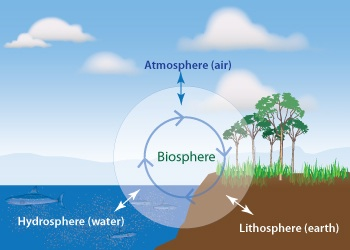

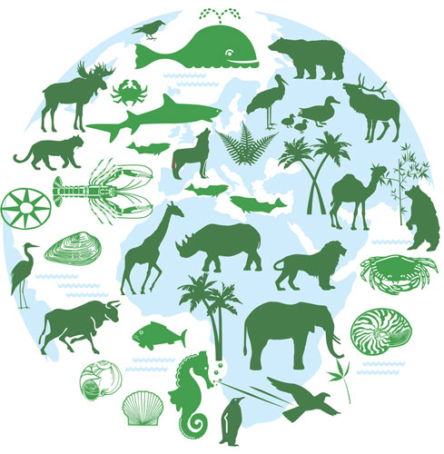

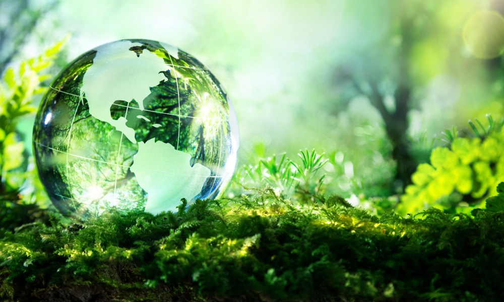

“A thing is right when it tends to preserve the integrity, stability, and beauty of the biotic community. It is wrong when it tends otherwise” -Aldo Leopold

## Painting Chalon Sombrero mountain in Peru…WHY?

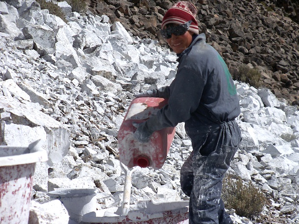

## Albedo

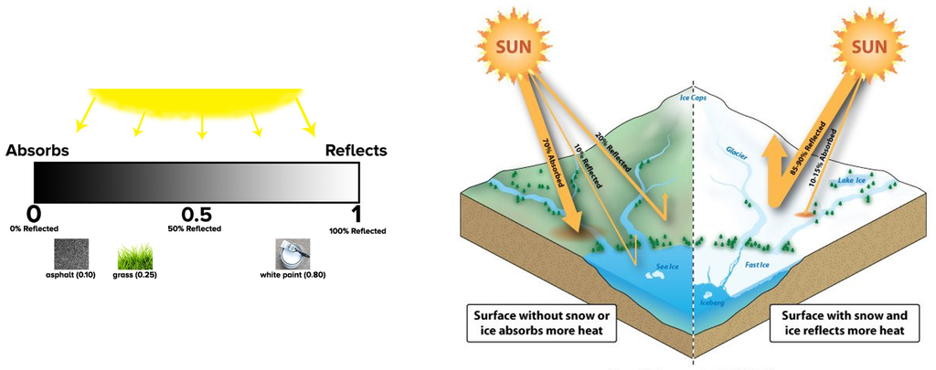

## Global albedo is highly variable in time and place

[video not shown]

## Albedo *positive feedbacks* and Snowball Earth

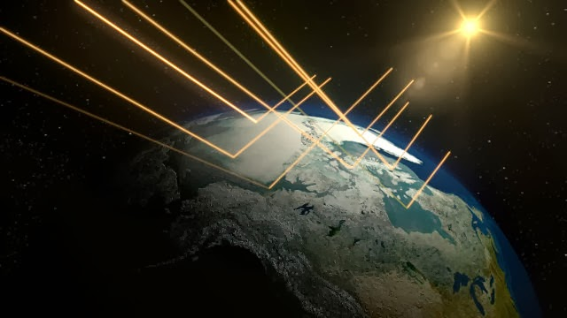

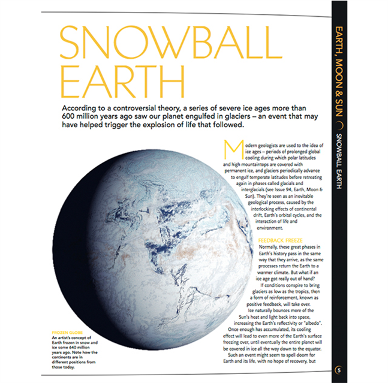

**Earth’s average albedo is ~0.3, keeping surface @ 15°C**

**Do you think global albedo is stable?**

**Albedo: cold generates cold but…..**

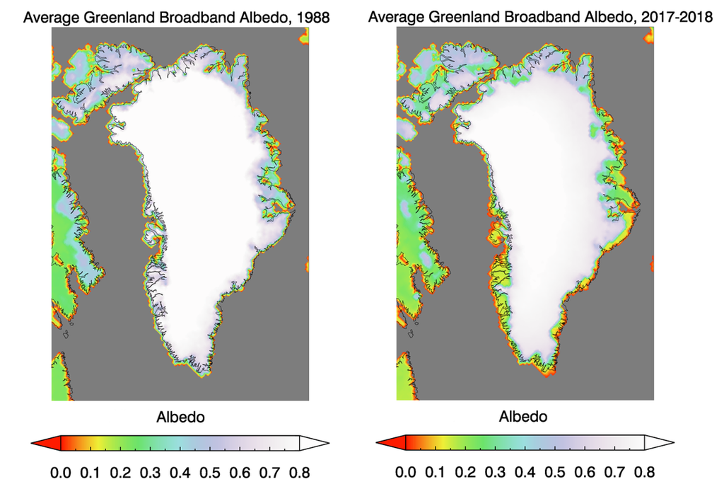

[figure not shown]

## Sun is the Earth’s primary form of heat energy, via radiation

- **~1/3 of sunlight energy reflects back to space**
- **Rest is absorbed by land, *oceans*, and atmosphere**
  - majority of absorbed radiation stored as ocean heat
  - ocean heat buffers land surfaces from warming
- **Exact amount absorbed depends on both surface and atmosphere (greenhouse effect)**
- **The balance of incoming and outgoing radiation makes up the Earth Energy Budget**

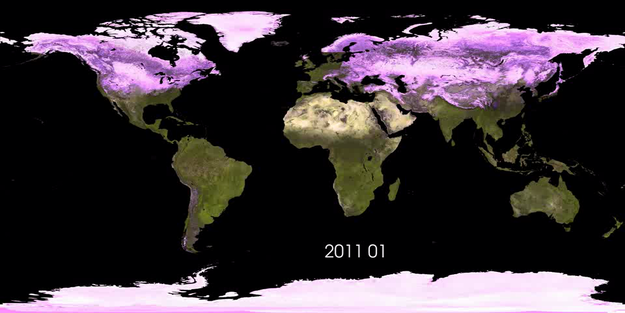

[figure not shown]

## Why clouds are cool…

[figure not shown]

[figure not shown]

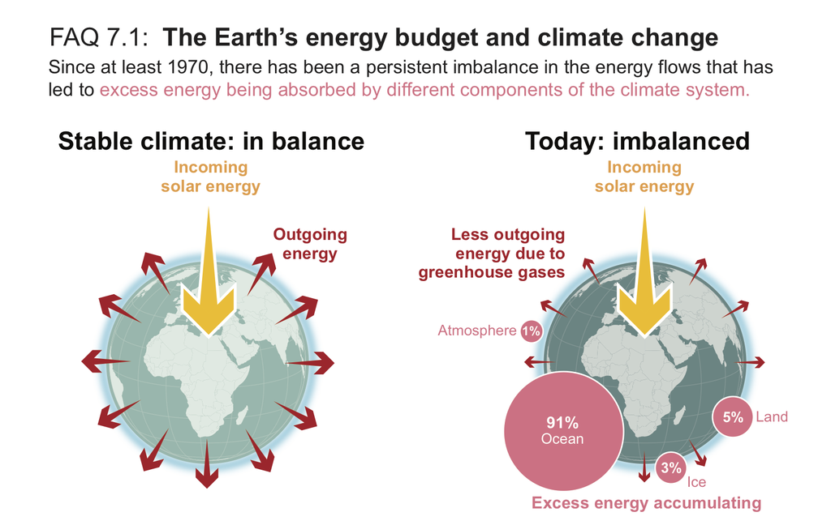

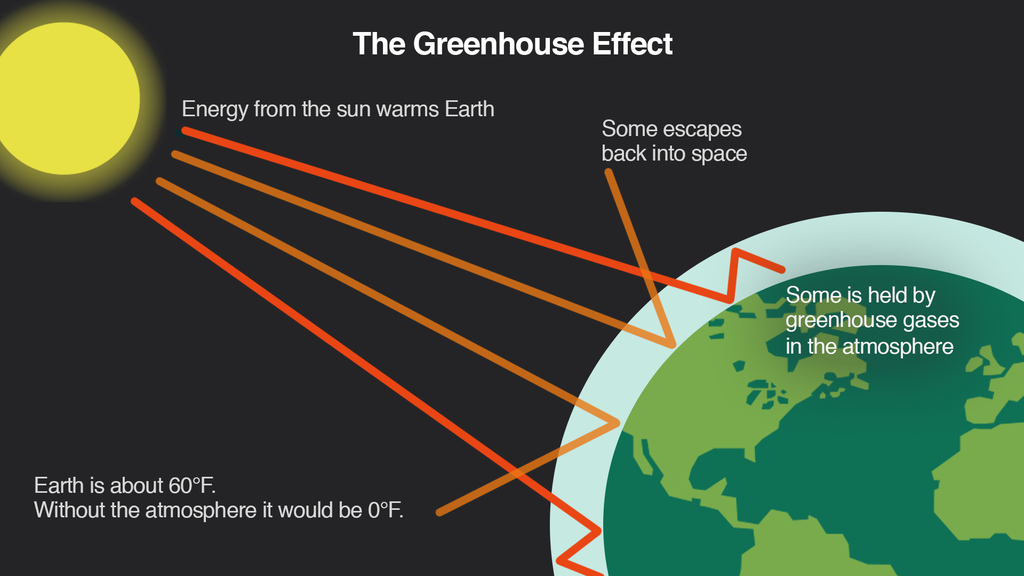

## Composition of the atmosphere alters the greenhouse effect

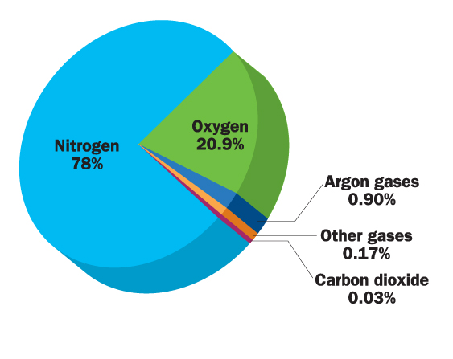

- **Gases have different RESIDENCE TIMES in the atmosphere**
  - N<sub>2</sub> = 13 million years (inert)
  - O<sub>2</sub> = 10,000 years (inert)
  - **N<sub>2</sub>0 = 114 years**
  - **CH<sub>4</sub> (methane) = 12 years**
  - **CO<sub>2</sub> = 5-200 years (1/2 removed quickly)**
- **Water vapor is reactive and highly variable**
  - **10 day residence time**
  - seasonally and spatially

## Greenhouse gas absorption spectra for outgoing radiation

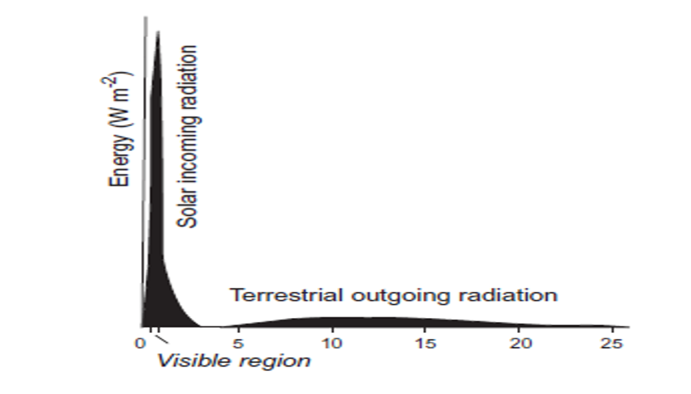

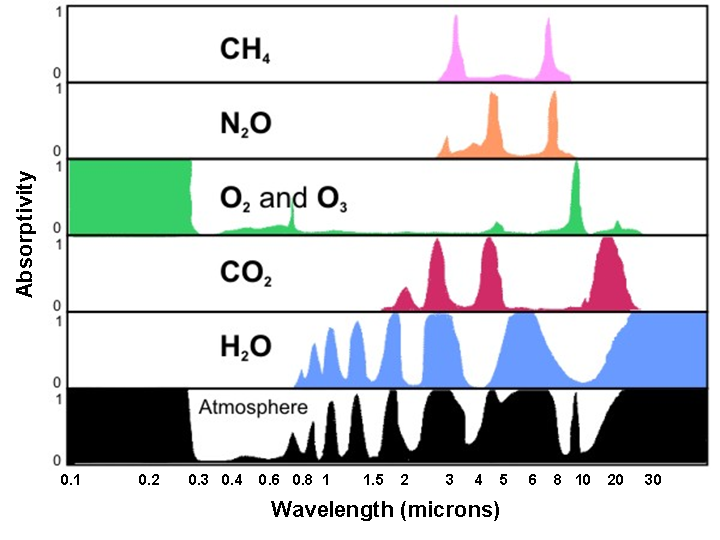

## Changes in composition impact *atmospheric heating*

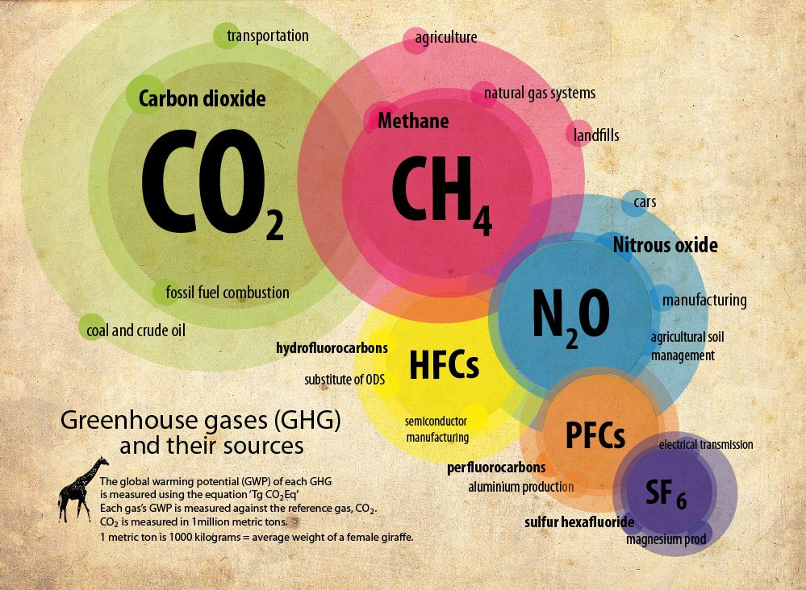

## Water vapor is the most abundant greenhouse gas

- **NASA recently confirmed heat-trapping effect of water vapor in the atmosphere**
  - critical component of climate change
  - collects at tropical latitudes
- **2x climate warming caused by increased CO<sub>2</sub>**
- **Difficult to quantify**
  - residence time in days
  - consider cloud variability

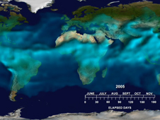

## Solar energy & water cycle connected

**Water cycle = movement of water within the earth and atmosphere**

**25% of incoming solar energy leaves the surface through evaporation**

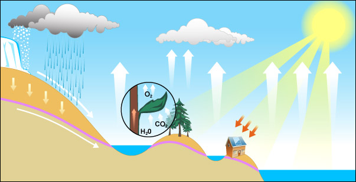

## Evapotranspiration: Energetics of water movement

**Water enters the atmosphere as vapor from surfaces (evaporation) and from leaves (transpiration)**

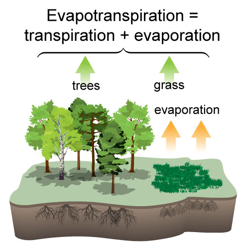

## Global water cycle: 577,000 km<sup>3</sup> of water circulates each year

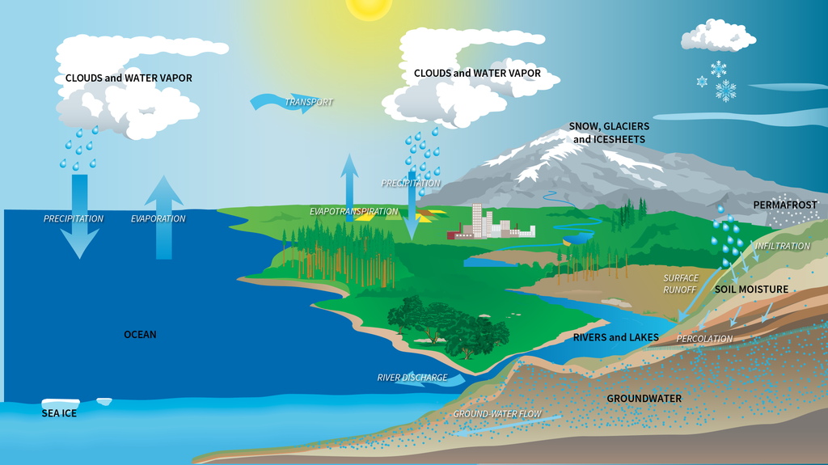

## Global water cycle: Residence times matter for availability

**Water is exists in different ‘storage pools’ for variable amounts of time**

[figure not shown]

## Fresh water for humans….

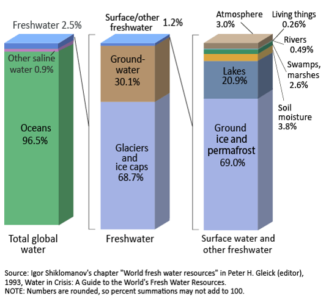

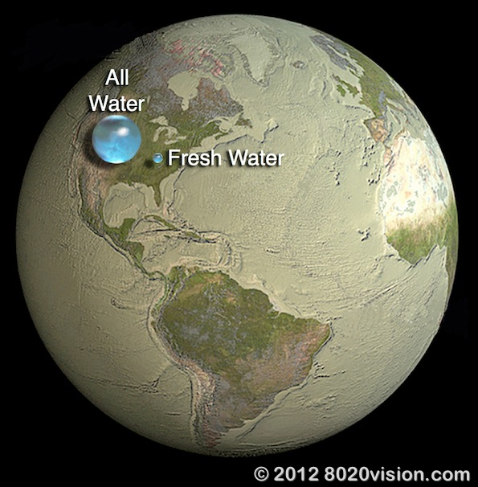

## Testable concepts in this lecture

- **The components of the Earth’s energy budget**
  - the role of albedo
- **The greenhouse gas effect (atmospheric heating)**
  - major greenhouse gases
- **How water moves and is stored within global water cycle**
  - evapotranspiration has the connection between energy flow and the water cycle